# Report Notebook

### Per age group

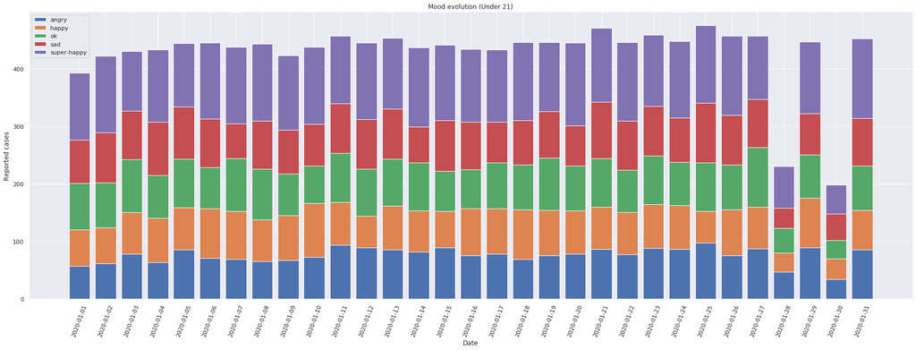

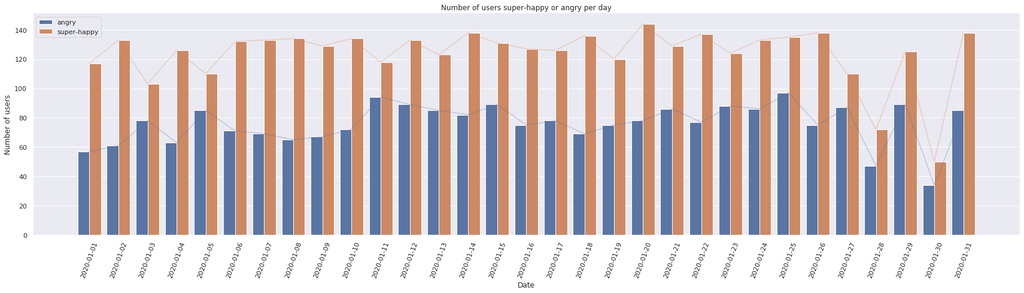

```
The overall percentage for each mood is:
```

```
super-happy    28.89
sad            18.46
ok             18.12
angry          17.71
happy          16.81
dtype: float64
```

```python
# 21 and under
s_df = s_moodtracker_df.merge(pop_df.query("userage <= 21")[["userid"]], how = 'inner', on='userid')
mood_evolution(s_df, 'Under 21')

# Plot extreme moods comparison
mood_comparison(s_df, 'angry', 'super-happy')

# Print "mood percentage"
print("The overall percentage for each mood is:")
display(round(s_df.mood.value_counts(normalize=True)*100, 2))
```

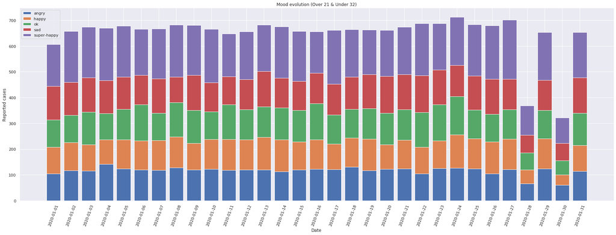

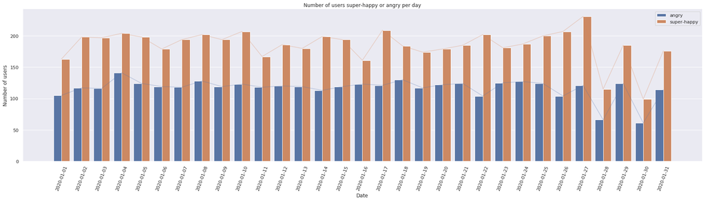

```
The overall percentage for each mood is:
```

```
super-happy    28.55
sad            18.82
ok             18.03
angry          17.94
happy          16.66
dtype: float64
```

```python
# Over 21 and under 32
s_df = s_moodtracker_df.merge(pop_df.query("userage > 21 and userage < 32")[["userid"]], how = 'inner', on='userid')
mood_evolution(s_df, 'Over 21 & Under 32')

# Plot extreme moods comparison
mood_comparison(s_df, 'angry', 'super-happy')

# Print "mood percentage"
print("The overall percentage for each mood is:")
display(round(s_df.mood.value_counts(normalize=True)*100, 2))
```

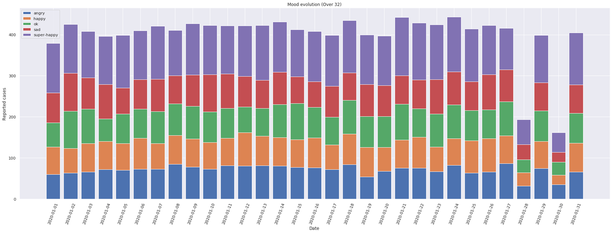

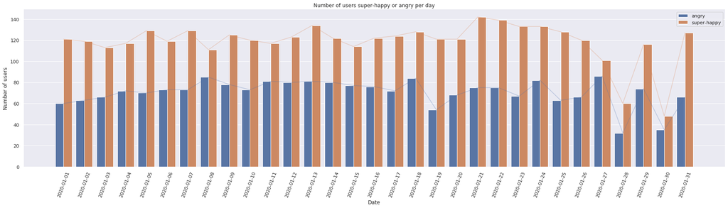

```
The overall percentage for each mood is:
```

```
super-happy    29.65
ok             18.08
sad            18.06
angry          17.64
happy          16.57
dtype: float64
```

```python
# Over 32
s_df = s_moodtracker_df.merge(pop_df.query("userage >= 32")[["userid"]], how = 'inner', on='userid')
mood_evolution(s_df, 'Over 32')

# Plot extreme moods comparison
mood_comparison(s_df, 'angry', 'super-happy')

# Print "mood percentage"
print("The overall percentage for each mood is:")
display(round(s_df.mood.value_counts(normalize=True)*100, 2))
```

On the age groups, we can see that the group of users under 21 years old show more diversity in the moods reported each day.

## Content Consumption

In this section we will go over the content consumption, and see how it relates to the users and it's evolution during the month under analysis.

```python
# Fetch tables from database
content_display_df = pd.read_sql_table('content_display', engine)
content_access_df = pd.read_sql_table('content_access', engine)
content_df = pd.read_sql_table('content', engine)
```

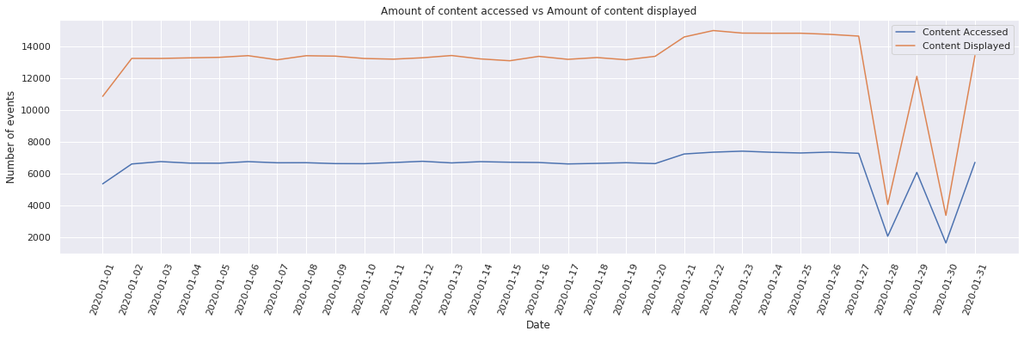

```python
# Get the date from the timestamps
content_access_df["accessedat_date"] = content_access_df["accessedat"].apply(lambda x: x.strftime('%Y-%m-%d'))
content_display_df["displayedat_date"] = content_display_df["displayedat"].apply(lambda x: x.strftime('%Y-%m-%d'))

# Count the number of contents accesses each day
content_access_logday = content_access_df.accessedat_date.value_counts().sort_index().reset_index()
content_access_logday.columns = ['accessedat_date', 'total_day_registers']

# Count the number of contents displays each day
content_display_logday = content_display_df.displayedat_date.value_counts().sort_index().reset_index()
content_display_logday.columns = ['displayedat_date', 'total_day_registers']

# Plot content accessed vs content displayed
fig = plt.figure(figsize=(20,5))

sns.lineplot(x='accessedat_date',
            y='total_day_registers',
            data=content_access_logday)

sns.lineplot(x='displayedat_date',
            y='total_day_registers',
            data=content_display_logday)

plt.title("Amount of content accessed vs Amount of content displayed")
plt.xlabel('Date')
plt.ylabel('Number of events')
plt.tick_params('x',labelrotation=70)

plt.legend(('Content Accessed', 'Content Displayed'))
plt.show()
```

We can see in this plot that content access and display seem to be positively correlated, with content access following a similar trend to content displayer, albeit with less abrupt increases, resulting in a smoother curve. Just like in the previous report, there is a significant drop of content displayed and accessed on 2020-01-28 and on 2020-01-30.

To further understand the relationship between these two variables, it could be interesting to investigate the overlap between content displayed to an user and the content the user actually accesses.

```python
# Prepare dataframes for appending
content_access_df["event_timestamp"] = content_access_df["accessedat"]
content_access_df["event_date"] = content_access_df["accessedat_date"]
content_access_df["event"] = "access"

content_display_df["event_timestamp"] = content_display_df["displayedat"]
content_display_df["event_date"] = content_display_df["displayedat_date"]
content_display_df["event"] = "display"

# Copy dataframes
a_content_display_df = content_display_df.drop(columns = ["displayedat", "displayedat_date"]).copy()
a_content_access_df = content_access_df.drop(columns = ["accessedat", "accessedat_date"]).copy()

# Join both dataframes in a single one for grouping
event_df = pd.concat([a_content_access_df, a_content_display_df]).reset_index().drop(columns='index')
event_df.sort_values(["userid", "event_timestamp"], inplace=True)
event_df_group = event_df.groupby(["userid", "event_date", "contentid"]).event.agg(["unique", "nunique"]).reset_index()
```

```python
# We can now check when a displayed content was accessed
print("First rows of the grouped table")
event_df_group["unique"] = event_df_group["unique"].apply(lambda x: ' | '.join(x))
event_df_group.head()
```

```
First rows of the grouped table
```

|  | userid | event_date | contentid | unique | nunique |
| --- | --- | --- | --- | --- | --- |
| 0 | 00038938-418a-4c53-8dc8-3cac021942cf | 2020-01-01 | 20 | access | 1 |
| 1 | 00038938-418a-4c53-8dc8-3cac021942cf | 2020-01-01 | 54 | access | 1 |
| 2 | 00038938-418a-4c53-8dc8-3cac021942cf | 2020-01-01 | 67 | display | 1 |
| 3 | 00038938-418a-4c53-8dc8-3cac021942cf | 2020-01-01 | 76 | display \| access | 2 |
| 4 | 00038938-418a-4c53-8dc8-3cac021942cf | 2020-01-01 | 93 | display | 1 |

We can now check 3 groups of contents:

- Contents displayed to an user and accessed the same day
- Contents displayed to an user and not accessed the same day
- Contents accessed by an user without being displayed on the same day.

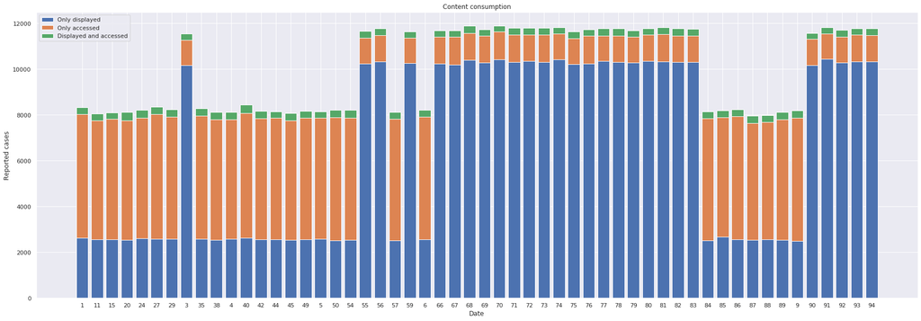

```python
# Content accessed and displayed
suc_sug_content = event_df_group.query("nunique == 2").groupby("contentid").agg({"event_date" : "count"}).reset_index()
# Content accessed but not displayed
suc_sug_content1 = event_df_group.query("nunique == 1").query("unique.str.contains('access')").groupby("contentid").agg({"event_date" : "count"}).reset_index()
# Content displayed but not accessed
suc_sug_content2 = event_df_group.query("nunique == 1").query("unique.str.contains('display')").groupby("contentid").agg({"event_date" : "count"}).reset_index()

# Plot the results

fig = plt.figure(figsize=(30,10))

p1=plt.bar(x = "contentid",
        height = "event_date",
       data=suc_sug_content2)

p2=plt.bar(x = "contentid",
        height = "event_date",
       data=suc_sug_content1,
       bottom=suc_sug_content2["event_date"])

p3=plt.bar(x = "contentid",
        height = "event_date",
       data=suc_sug_content,
       bottom=suc_sug_content1["event_date"]+suc_sug_content2["event_date"])


plt.title("Content consumption")
plt.xlabel("Date")
plt.ylabel("Reported cases")
plt.legend((p1,p2,p3), ("Only displayed", "Only accessed", "Displayed and accessed"))

plt.show()
```

The previous plots show us the interaction between a content being displayed and accessed by the same user on the same day.

- It is clear that some contents are more pushed towards the users than others, as seen in the cases where the "only displayed" bar of certain contents is larger than the complete bar of others. These contents have a smaller probability of being accessed without being displayed to the user, and thus have to be pushed harder towards the user.
- The other group of contents is more accessed without being displayed than simply being displayed, suggesting users are more proactive in accessing these contents.
- Only a small fraction of contents are displayed to the user and accessed on the same day. This can mean several things:
  - Users are already aware of which contents they want to consume or not, thus the large values of "Only accessed" for some contents.
  - Users access contents that are displayed to them early on, but as time goes on, they are able to access the contents they care about without them being displayed to them.

## Closing remarks

In this report we:

- Described the population;
- Explored the moodtracker data, studied it's use over time and how users use it.
- Described and compared the emotional state and its evolution of different groups within our population.
- Analysed the content comsumption.

The main learnings are:

- We learned that the population can be grouped in different ways, with slightly different results depending on the criteria. A further study on this subject with a larger dataset could help further define and refine the groups.
- We were able to find some pattern when it comes to the usage of the moodtracker feature, that could potentially be used to tweak the tool itself.
- We found that the general drop in content consumption registered at the end of the month also occured in the use of the moodtracker feature.
  - We identified a drop in the number of users, however it cannot be definitively stated that this was the reason for the drop, since we don't have visibility into the following week or month.
  - We saw that both the amount of content displayed/accessed also suffered a drop in the same day.

We do a final analysis to try to understand the reason behind this general drop in interaction on the end of the month.

```python
# Let's compute the number of users of the moodtracker per hour
moodtracker_df["hour"] = pd.to_datetime(moodtracker_df.trackedat).hour
users_per_hour=moodtracker_df.groupby(["hour", "trackedat_date"])["userid"].nunique().reset_index()
display(users_per_hour.userid.describe())
```

```
count    537.000000
mean     174.420857
std      79.923715
min      7.000000
25%      190.000000
50%      208.000000
75%      220.000000
max      275.000000
Name: userid, dtype: float64
```

We see that 25% of the hours in this month register less than 190 logs. Let's use that number as our threshold.

```python
# Number of day/hours where less than 190 logs per hour were registered
hour_df = pd.DataFrame(users_per_hour.query("userid < 190").groupby(["hour"])["trackedat_date"].unique()).reset_index()
print("Hours/day below our threshold value")
display(hour_df)
```

```
Hours/day below our threshold value
```

|  | hour | trackedat_date |
| --- | --- | --- |
| 0 | 0 | [2020-01-16, 2020-01-29] |
| 1 | 1 | [2020-01-12, 2020-01-15, 2020-01-29] |
| 2 | 2 | [2020-01-18, 2020-01-29] |
| 3 | 3 | [2020-01-21, 2020-01-22, 2020-01-23, 2020-01-24, 2020-01-25, 2020-01-26, 2020-01-27, 2020-01-28, 2020-01-29, 2020-01-30] |
| 4 | 4 | [2020-01-21, 2020-01-22, 2020-01-23, 2020-01-24, 2020-01-25, 2020-01-26, 2020-01-27, 2020-01-28, 2020-01-29, 2020-01-30] |
| 5 | 5 | [2020-01-21, 2020-01-22, 2020-01-23, 2020-01-24, 2020-01-25, 2020-01-26, 2020-01-27, 2020-01-28, 2020-01-29, 2020-01-30] |
| 6 | 6 | [2020-01-21, 2020-01-22, 2020-01-23, 2020-01-24, 2020-01-25, 2020-01-26, 2020-01-27, 2020-01-28, 2020-01-29, 2020-01-30] |
| 7 | 7 | [2020-01-21, 2020-01-22, 2020-01-23, 2020-01-24, 2020-01-25, 2020-01-26, 2020-01-27, 2020-01-28, 2020-01-29, 2020-01-30] |
| 8 | 8 | [2020-01-21, 2020-01-22, 2020-01-23, 2020-01-24, 2020-01-25, 2020-01-26, 2020-01-27, 2020-01-28, 2020-01-29, 2020-01-30] |
| 9 | 9 | [2020-01-21, 2020-01-22, 2020-01-23, 2020-01-24, 2020-01-25, 2020-01-26, 2020-01-27, 2020-01-28, 2020-01-29, 2020-01-30] |
| 10 | 10 | [2020-01-21, 2020-01-22, 2020-01-23, 2020-01-24, 2020-01-25, 2020-01-26, 2020-01-27, 2020-01-28, 2020-01-29, 2020-01-30] |
| 11 | 11 | [2020-01-21, 2020-01-22, 2020-01-23, 2020-01-24, 2020-01-25, 2020-01-26, 2020-01-27, 2020-01-28, 2020-01-29, 2020-01-30] |
| 12 | 12 | [2020-01-10, 2020-01-15, 2020-01-16, 2020-01-28] |
| 13 | 13 | [2020-01-14, 2020-01-28] |
| 14 | 14 | [2020-01-11, 2020-01-15, 2020-01-25, 2020-01-28] |
| 15 | 15 | [2020-01-11, 2020-01-16, 2020-01-17, 2020-01-28] |
| 16 | 16 | [2020-01-15, 2020-01-20, 2020-01-28] |
| 17 | 17 | [2020-01-05, 2020-01-19, 2020-01-28] |
| 18 | 18 | [2020-01-28] |
| 19 | 19 | [2020-01-01, 2020-01-09, 2020-01-28] |
| 20 | 20 | [2020-01-01, 2020-01-28] |
| 21 | 21 | [2020-01-02, 2020-01-18, 2020-01-28] |
| 22 | 22 | [2020-01-28] |
| 23 | 23 | [2020-01-04, 2020-01-14, 2020-01-16, 2020-01-28] |

The table above shows us that the period of time between 3 and 11 AM are most likely to have few users, even on what seem to be "regular" days, such as 2020-01-23. On the remainder hours we often find 2020-01-28, the day with the largest drop in user interaction.

We will look into these days as our baselines, and compare them with the days that surround 2020-01-28 and 2020-01-30 (2020-01-27, 2020-01-29 and 2020-01-31).

We are going to split our comparisons in 3 intervals:

- 0:00 to 2:00
- 3:00 to 11:00
- 12:00 to 23:00

```python
# Compare our 4 days
user_hour_comparison = users_per_hour.query("trackedat_date == '2020-01-28'").merge(
    users_per_hour.query("trackedat_date == '2020-01-23'"), on='hour',suffixes =('_28', '_23')).merge(
    users_per_hour.query("trackedat_date == '2020-01-27'"), on='hour',suffixes =('', '_27')).merge(
    users_per_hour.query("trackedat_date == '2020-01-29'"), on='hour',suffixes =('_27', '_29')).merge(
    users_per_hour.query("trackedat_date == '2020-01-30'"), on='hour',suffixes =('_29', '_30'), how='left').merge(
    users_per_hour.query("trackedat_date == '2020-01-31'"), on='hour',suffixes =('_30', '_31'), how='left')

user_hour_comparison.rename(columns = {"trackedat_date" : "trackedat_date_30",
                                      "userid":'userid_30'},
                           inplace=True)

print("First interval table")
display(user_hour_comparison.query("hour >= 0 & hour <= 2"))
```

```
First interval table
```

|  | hour | trackedat_date_28 | userid_28 | trackedat_date_23 | userid_23 | trackedat_date_27 | userid_27 | trackedat_date_29 | userid_29 | trackedat_date_30 | userid_30 | trackedat_date_31 | userid_31 |
| --- | --- | --- | --- | --- | --- | --- | --- | --- | --- | --- | --- | --- | --- |
| 0 | 0 | 2020-01-28 | 237 | 2020-01-23 | 221 | 2020-01-27 | 235 | 2020-01-29 | 23 | 2020-01-30 | 232.0 | NaN | NaN |
| 1 | 1 | 2020-01-28 | 230 | 2020-01-23 | 233 | 2020-01-27 | 207 | 2020-01-29 | 16 | 2020-01-30 | 228.0 | NaN | NaN |
| 2 | 2 | 2020-01-28 | 234 | 2020-01-23 | 191 | 2020-01-27 | 214 | 2020-01-29 | 16 | 2020-01-30 | 237.0 | NaN | NaN |

In our first interval we see that with the exception of 2020-01-29, all the other days showed similair amount of users, suggesting that everything was ok up to this hour.

```python
print("Second interval table")
display(user_hour_comparison.query("hour >= 3 & hour <= 11"))
```

```
Second interval table
```

|  | hour | trackedat_date_28 | userid_28 | trackedat_date_23 | userid_23 | trackedat_date_27 | userid_27 | trackedat_date_29 | userid_29 | trackedat_date_30 | userid_30 | trackedat_date_31 | userid_31 |
| --- | --- | --- | --- | --- | --- | --- | --- | --- | --- | --- | --- | --- | --- |
| 3 | 3 | 2020-01-28 | 18 | 2020-01-23 | 13 | 2020-01-27 | 11 | 2020-01-29 | 14 | 2020-01-30 | 12.0 | NaN | NaN |
| 4 | 4 | 2020-01-28 | 17 | 2020-01-23 | 10 | 2020-01-27 | 14 | 2020-01-29 | 22 | 2020-01-30 | 27.0 | NaN | NaN |
| 5 | 5 | 2020-01-28 | 19 | 2020-01-23 | 15 | 2020-01-27 | 14 | 2020-01-29 | 15 | 2020-01-30 | 15.0 | NaN | NaN |
| 6 | 6 | 2020-01-28 | 18 | 2020-01-23 | 16 | 2020-01-27 | 17 | 2020-01-29 | 18 | 2020-01-30 | 10.0 | NaN | NaN |
| 7 | 7 | 2020-01-28 | 20 | 2020-01-23 | 16 | 2020-01-27 | 14 | 2020-01-29 | 18 | 2020-01-30 | 11.0 | NaN | NaN |
| 8 | 8 | 2020-01-28 | 19 | 2020-01-23 | 10 | 2020-01-27 | 16 | 2020-01-29 | 8 | 2020-01-30 | 19.0 | NaN | NaN |
| 9 | 9 | 2020-01-28 | 11 | 2020-01-23 | 13 | 2020-01-27 | 16 | 2020-01-29 | 22 | 2020-01-30 | 13.0 | NaN | NaN |
| 10 | 10 | 2020-01-28 | 11 | 2020-01-23 | 23 | 2020-01-27 | 16 | 2020-01-29 | 9 | 2020-01-30 | 12.0 | NaN | NaN |
| 11 | 11 | 2020-01-28 | 16 | 2020-01-23 | 14 | 2020-01-27 | 17 | 2020-01-29 | 13 | 2020-01-30 | 13.0 | NaN | NaN |

This period is the one with less activity for these days. This is consistent for everyday between 2020-01-21 and 2020-01-30, as seen on the table depicting the "Hours/day below our threshold value".

```python
print("Third interval table")
display(user_hour_comparison.query("hour >=12 & hour <= 23"))
```

```
Third interval table
```

|  | hour | trackedat_date_28 | userid_28 | trackedat_date_23 | userid_23 | trackedat_date_27 | userid_27 | trackedat_date_29 | userid_29 | trackedat_date_30 | userid_30 | trackedat_date_31 | userid_31 |
| --- | --- | --- | --- | --- | --- | --- | --- | --- | --- | --- | --- | --- | --- |
| 12 | 12 | 2020-01-28 | 22 | 2020-01-23 | 217 | 2020-01-27 | 205 | 2020-01-29 | 195 | NaN | NaN | 2020-01-31 | 273.0 |
| 13 | 13 | 2020-01-28 | 12 | 2020-01-23 | 218 | 2020-01-27 | 217 | 2020-01-29 | 252 | NaN | NaN | 2020-01-31 | 255.0 |
| 14 | 14 | 2020-01-28 | 11 | 2020-01-23 | 228 | 2020-01-27 | 213 | 2020-01-29 | 196 | NaN | NaN | 2020-01-31 | 234.0 |
| 15 | 15 | 2020-01-28 | 18 | 2020-01-23 | 216 | 2020-01-27 | 221 | 2020-01-29 | 230 | NaN | NaN | 2020-01-31 | 242.0 |
| 16 | 16 | 2020-01-28 | 17 | 2020-01-23 | 231 | 2020-01-27 | 216 | 2020-01-29 | 228 | NaN | NaN | 2020-01-31 | 253.0 |
| 17 | 17 | 2020-01-28 | 22 | 2020-01-23 | 221 | 2020-01-27 | 222 | 2020-01-29 | 243 | NaN | NaN | 2020-01-31 | 236.0 |
| 18 | 18 | 2020-01-28 | 12 | 2020-01-23 | 231 | 2020-01-27 | 230 | 2020-01-29 | 246 | NaN | NaN | 2020-01-31 | 275.0 |
| 19 | 19 | 2020-01-28 | 7 | 2020-01-23 | 202 | 2020-01-27 | 230 | 2020-01-29 | 215 | NaN | NaN | 2020-01-31 | 245.0 |
| 20 | 20 | 2020-01-28 | 12 | 2020-01-23 | 199 | 2020-01-27 | 220 | 2020-01-29 | 251 | NaN | NaN | 2020-01-31 | 245.0 |
| 21 | 21 | 2020-01-28 | 8 | 2020-01-23 | 206 | 2020-01-27 | 232 | 2020-01-29 | 208 | NaN | NaN | 2020-01-31 | 265.0 |
| 22 | 22 | 2020-01-28 | 10 | 2020-01-23 | 232 | 2020-01-27 | 227 | 2020-01-29 | 208 | NaN | NaN | 2020-01-31 | 233.0 |
| 23 | 23 | 2020-01-28 | 16 | 2020-01-23 | 232 | 2020-01-27 | 236 | 2020-01-29 | 225 | NaN | NaN | 2020-01-31 | 269.0 |

Here we finally see the biggest difference between what happens on 2020-01-28, 2020-01-30 and the other days. The number of users we see for each hour is several times smaller on the 28th than on the other days, that actually present very similar values amongst themselves. On the case of 2020-01-30 there aren't even registers.

Recall that on the first interval table we saw that the first hours of the 29th also showed some weird values in the first hours of the day - the hours following the end of the 28th.

Leads me to believe that the possible explanation for this is some technical problem on the website or some deployment and not a loss of users.

The small number of registers on the third interval for the 28th suggests that the website was working, however only a limited amount of users could use it (it could be either a technical problem or a reduced number of users testing something).

The complete absence of registers for the 30th during the interval strongly hints that the moodtracker tool was unacessible. Another possibility for this day is that something happened with the database and nothing was written to it on this period, but given the precendent of what happened on the 28th I find that unlikely.